# Singapore Private vs. Fleet AV SEM

Joanna Moody and Tianyi Fan

July 3, 2020

## Initialization

### Load Packages

```r
library(dplyr)
library(reshape2) #for melt function
library(car)
library(ggplot2)
library(viridis) #color-blind friendly palette
library(forcats) #for easy factor level reordering
library(lavaan)
#library(lavaanPlot)
```

### Load Data

```r
#Read in data, delete headers, and make working copy of data
Data_raw <- read.csv("./FullRawData/MITei Mobility Culture Survey - Singapore_April 16, 2019_14.12.csv", stringsAsFactors=FALSE)
Data_raw <- Data_raw[3:nrow(Data_raw),]  #remove extra header rows
Data_SG <- Data_raw

#Create simple function that reverses a 7-point Likert scale
flipscale <- function(x) {( 8 - x )}
```

### Data Cleaning

```r
### Cleaning sociodemographic variables
Data_SG <- Data_SG %>% mutate(DOB = as.numeric(as.character(Age)),
                              Age = 2019 - DOB,
                              Male = ifelse(Gender=="1", 1, 0),
                              Educ = as.numeric(Educ),
                              ColDeg = ifelse(Educ==5, 1, 0),
                              GradDeg = ifelse(Educ==6 | Educ==7, 1, 0),
                              BelowSecondary = ifelse(Educ==1, 1, 0),
                              Secondary = ifelse(Educ==2, 1, 0),
                              PostSecondary = ifelse(Educ==3, 1, 0),
                              Diploma = ifelse(Educ==4, 1, 0),
                              University = ifelse(Educ>4, 1, 0),
                              Employ = as.numeric(Employ),
                              Employed = ifelse(Employ==6 | Employ==7, 1, 0),
                              Student = ifelse(Employ==9, 1, 0),
                              HHPers = as.numeric(HHPers),
                              Kids = as.numeric(Kids),
                              Kids = ifelse(Kids>1, 1, 0),  #Kids=1 indicates zero kids
                              HHInc = ifelse(HHInc=="19", NA, as.numeric(HHInc)),
                              HHCars = as.numeric(HHCars),
                              CarOwner = ifelse(HHCars > 1, 1, 0) #HHCars=1 indicates zero cars
                              )

Data_SG$HHCars <- car::recode(Data_SG$HHCars, "1=0; 2=1; 3=2; 4=3")

#HHInc: What is your household monthly income (including employer CPF contributions, if applicable) in Singapore dollars?
#1=Below $1000=500, 2=$1000-2499=1750, 3=$2500-3999=3250, 4=$4000-4999=4500, (no 5),
#6=$5000-5999=5500, 7=$6000-6999=6500, 8=$7000-7999=7500, 9=$8000-8999=9500,
#10=$9000-9999=9500, 11=$10000-10999=10500, 12=$11000-12999=12000, 13=$13000-14999=14000,
#(no 14), 15=$15000-17499=16250, (no 16), 17=$17500-19999=18750, 18=$20000 or more=21250,
#19(unknown)
Data_SG$HHInc <- car::recode(Data_SG$HHInc,
                             "1=500; 2=1750; 3=3250; 4=4500; 6=5500; 7=6500;
                             8=7500; 9=8500; 10=9500; 11=10500; 12=12000;
                             13=14000; 15=16250; 17=18750; 18=21250")
Data_SG$HHInc_yearly <- Data_SG$HHInc*12


#Q8. "What percentage of your monthly trips do you currently fulfill by each of the following modes? (trips can include, but are not limited to, any travel among home, work, school, shopping, food, recreation, healthcare or other social service/facility, etc.)"
#  _1 = Private/Personal car
#  _2 = Taxi
#  _3 = Ridehailing: private service (e.g. GrabCar Economy or Premium, Ryde, or GOJEK GOCAR)
#  _4 = Ridehailing: shared service (e.g. GrabShare or Ryde Carpool)
#  _5 = Motorcycle or scooter
#  _6 = MRT/LRT
#  _7 = Bus
#  _8 = Bicycle
#  _9 = Walk

#Based on share of travel by mode, categorize users by frequency of use.
#  Combine bus and rail into PT; combine walk and bike into NMT.

#RH_Use: Have you ever used these ridehailing services (as a passenger)?"
# 1 = "No: I have never used a ridehailing service"
# 2 = "Yes: I have used a private (or exclusive) ridehailing service"
# 3 = "Yes: I have used a shared (or pooled) ridehailing service"

Data_SG <- Data_SG %>% mutate(Car_Share = as.numeric(Q8_1),
                              Taxi_Share = as.numeric(Q8_2),
                              ERH_Share = as.numeric(Q8_3), #ERH = exclusive ride-hailing
                              PRH_Share = as.numeric(Q8_4), #PRH = pooled ride-hailing
                              RH_Share = ERH_Share + PRH_Share,
                              Fleet_Share = RH_Share + Taxi_Share,
                              PT_Share = as.numeric(Q8_6) + as.numeric(Q8_7),
                              NMT_Share = as.numeric(Q8_8) + as.numeric(Q8_9),
                              NMT_SuperUser = ifelse(NMT_Share >= 20, 1, 0), #110 individuals
                              NMT_FreqUser = ifelse(NMT_Share %in% 10:19, 1, 0), #242 individuals
                              NMT_RegUser = ifelse(NMT_Share %in% 1:9, 1, 0), #214 individuals
                              NMT_NonUser = ifelse(NMT_Share < 1, 1, 0), #234 individuals
                              PT_SuperUser = ifelse(PT_Share >= 71, 1, 0),  #188
                              PT_FreqUser = ifelse(PT_Share %in% 46:70, 1, 0), #205
                              PT_RegUser = ifelse(PT_Share %in% 11:45, 1, 0), #231
                              PT_LowUser = ifelse(PT_Share < 11, 1, 0), #176
#cutoff based on summary statistics; only 71 individuals in the sample are non-users because Singapore is super transit-oriented
                              Car_SuperUser = ifelse(Car_Share >= 60, 1, 0),  #175
                              Car_FreqUser = ifelse(Car_Share %in% 20:59, 1, 0), #192
                              Car_RegUser = ifelse(Car_Share %in% 1:19, 1, 0), #147
                              Car_NonUser = ifelse(Car_Share < 1, 1, 0), #286
                              Taxi_FreqUser = ifelse(Taxi_Share >= 8, 1, 0), # 189
                              Taxi_RegUser = ifelse(Taxi_Share %in% 1:7, 1, 0), #185
                              Taxi_NonUser = ifelse(Taxi_Share < 1, 1, 0), #426
                              RH_FreqUser = ifelse(RH_Share >= 20, 1, 0), #183
                              RH_RegUser = ifelse(RH_Share %in% 1:19, 1, 0), #341
                              RH_NonUser = ifelse(RH_Share < 1, 1, 0), #279
                              RH_User = ifelse(RH_Use!="1", 1, 0),
                              Fleet_SuperUser = ifelse(Fleet_Share >= 30, 1, 0), #155
                              Fleet_FreqUser = ifelse(Fleet_Share %in% 13:29, 1, 0), #200
                              Fleet_RegUser = ifelse(Fleet_Share %in% 1:12, 1, 0), #221
                              Fleet_NonUser = ifelse(Fleet_Share < 1, 1, 0), #227
                              Fleet_User = ifelse(Fleet_NonUser==0, 1, 0))

#AV_Know    What is your current level of knowledge of autonomous vehicle technology?
#  1 = I have no knowledge of autonomous vehicles,
#  2 = I have little knowledge of autonomous vehicles (for example, I have heard of or seen them)
#  3 = I have a moderate knowledge of autonomous vehicles (for example, I have read about them),
#  4 = I have advanced knowledge of autonomous vehicles,
#  5 = I am a developer of autonomous vehicle technology
length(which(Data_SG$AV_Know==5)) #2 individuals in the sample are developers of AV technology
```

```
## [1] 2
```

```r
#AV_Ride    Have you ever ridden in an autonomous vehicle?  1-Yes, 2-No
length(which(Data_SG$AV_Ride==1)) #110 individuals claim to have ridden in an AV
```

```
## [1] 110
```

```r
Data_SG <- Data_SG %>% mutate(Exp = ifelse(AV_Ride == "1", 1, 0))
```

## Descriptive Statistics of Outcome Variables

### Data processing

```r
Data_SG <- Data_SG %>% mutate(PAV_Purch = flipscale(as.numeric(PAV_Purch_1)),
                              PAV_WTP = as.numeric(PAV_WTP),
                              PAV_WTP = ifelse(PAV_WTP > 1000000, 1000000, PAV_WTP),
                              PAV_Freq = as.numeric(PAV_Freq_1),
                              PrivFreqDiff = PAV_Freq - Car_Share,
                              SAV_IntendUse_1 = flipscale(as.numeric(SAV_IntendUse_1)), #for exclusive
                              SAV_IntendUse_2 = flipscale(as.numeric(SAV_IntendUse_2)), #for pooled
                              SAV_IntendUse_max = pmax(SAV_IntendUse_1, SAV_IntendUse_2),
                              SAV_IntendUse_mean = ((SAV_IntendUse_1 + SAV_IntendUse_2) / 2),
                              SAV_Freq_1 = as.numeric(SAV_Freq_1), #for exclusive
                              SAV_Freq_2 = as.numeric(SAV_Freq_2), #for pooled
                              SAV_Freq = SAV_Freq_1 + SAV_Freq_2,
                              SAV_Freq = ifelse(SAV_Freq > 100, 100, SAV_Freq),
                              FleetFreqDiff1 = SAV_Freq - RH_Share,
                              FleetFreqDiff2 = SAV_Freq - Fleet_Share,
                              SAV_HHCars = as.numeric(SAV_HHCars),
                              AV_IntendDiff = PAV_Purch - SAV_IntendUse_max
                              )

#Veh_Price_Used = "What was the purchase price of the vehicle (including the COE price, if applicable)?" (in Singaporean dollars)
# (no 1-3)
#  4-Below S$10,000,        11-S$70,000-79,999,
#  5-S$10,000-19,999,       12-S$80,000-89,999,
#  6-S$20,000-29,999,       13-S$90,000-99,999,
#  7-S$30,000-39,999,       14-S$100,000-149,999, (no 15)
#  8-S$40,000-49,999,       16-S$150,000-199,999,
#  9-S$50,000-59,999,       17-More than S$200,000
#  10-S$60,000-69,999,      18-N/A
Data_SG$Veh_Price_Used <- car::recode(Data_SG$Veh_Price_Used,
                             "4=5000; 5=15000; 6=25000; 7=35000; 8=45000; 9=55000; 10=65000; 11=75000;
                             12=85000; 13=95000; 14=125000; 16=175000; 17=225000; 18=18")

#Veh_Price_New = "What was the purchase price of the vehicle (including the COE price, if applicable)?" (in Singaporean dollars)
#  (no 1-3, 5, or 7)
#  4-Below S$50,000,        12-S$175,000-199,999,
#  6-S$50,000-74,999,       13-S$200,000-249,999,
#  8-S$75,000-99,999,       14-S$250,000-299,999,
#  9-S$100,000-124,999,     15-S$300,000-$349,999,
#  10-S$125,000-149,999,    16-More than S$350,000,
#  11-S$150,000-174,999,    17-N/A
Data_SG$Veh_Price_New <- car::recode(Data_SG$Veh_Price_New,
                             "4=25000; 6=62500; 8=87500; 9=112500; 10=137500; 11=162500;
                              12=187500; 13=225000; 14=275000; 15=325000; 16=375000; 17=17")

Data_SG <- Data_SG %>% mutate(Veh_Price_Used = ifelse(Veh_Price_Used=="18" | Veh_Price_Used=="",NA, as.numeric(Veh_Price_Used)),
                              Veh_Price_New = ifelse((Veh_Price_New=="17" | Veh_Price_New==""),NA, as.numeric(Veh_Price_New)),
                              VehPrice = ifelse(Veh_Used==1, Veh_Price_Used, Veh_Price_New),
                              #Vehicle price as percentage of household yearly income
                              VehPrice_Inc = ((VehPrice / HHInc_yearly) * 100),
                              #Willingness to pay for private AV as percentage of vehicle price
                              WTP_VehPrice = ((PAV_WTP / VehPrice) * 100),
                              #Willingness to pay for private AV as percentage of household yearly income
                              WTP_Inc = ((PAV_WTP / HHInc_yearly) * 100)
                              )

Data_SG$CarOwner_bin <- Data_SG$CarOwner
Data_SG$CarOwner <- as.factor(as.character(Data_SG$CarOwner))
levels(Data_SG$CarOwner) <- c("Non-car owner", "Car owner")

Data_SG_carowners <- filter(Data_SG, CarOwner=="Car owner") #501
Data_SG_nocars <- filter(Data_SG, CarOwner=="Non-car owner") #302
```

### Intended Adoption of Private vs. Shared AVs

PAV_Purch_1 = “If completely autonomous vehicles were available today, how likely would you be to purchase one as your next vehicle?” (Likert scale: 1 = Extremely likely to 7 = Extremely unlikely)

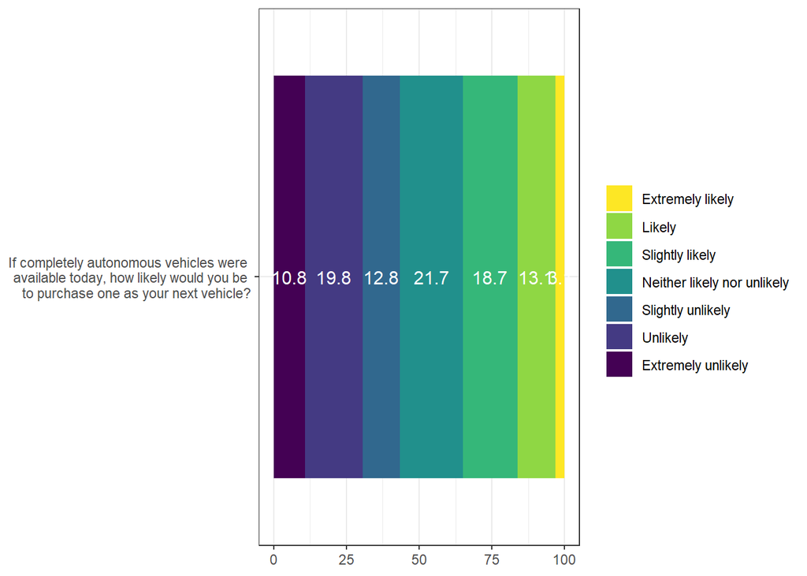

```r
levels.7pt.likely <- c("Extremely unlikely", "Unlikely", "Slightly unlikely", "Neither likely nor unlikely", "Slightly likely",  "Likely", "Extremely likely")

Data_SG$PAV_Purch_lik <- as.factor(as.character(Data_SG$PAV_Purch))
Data_SG$SAV_IntendUse_max_lik <- as.factor(as.character(Data_SG$SAV_IntendUse_max))
levels(Data_SG$PAV_Purch_lik) <- levels.7pt.likely
levels(Data_SG$SAV_IntendUse_max_lik) <- levels.7pt.likely

PAV_Purch_data <- Data_SG %>% group_by(PAV_Purch_lik) %>% summarise(n = length(PAV_Purch_lik), perc = (n/803)*100)
PAV_Purch_data$question <- "If completely autonomous vehicles were \n available today, how likely would you be \n to purchase one as your next vehicle?"
PAV_Purch_data$pos <- c(5.4, 20.7, 37, 54.3, 74.4, 90.3, 98.5)
colnames(PAV_Purch_data) <- c("answer", "n", "perc", "question", "pos")

p1 <- ggplot(data=PAV_Purch_data, aes(x=question)) +
        geom_bar(aes(y=perc, fill=forcats::fct_rev(answer)), position="stack", stat="identity") +
        geom_text(size=4, color="white", aes(y=pos, label=round(perc,1)))+
        scale_fill_viridis(discrete=TRUE, direction=-1) +
        #coord_cartesian(ylim = c(0,100), expand=FALSE) +
        theme_bw() +
        theme(axis.title=element_blank(), legend.title=element_blank(), legend.position="right")+
        coord_flip()
p1
```

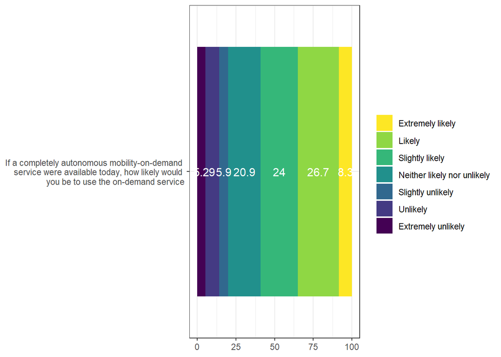

```r
SAV_Intend_data <- Data_SG %>% group_by(SAV_IntendUse_max_lik) %>% summarise(n = length(SAV_IntendUse_max_lik), perc = (n/803)*100)
SAV_Intend_data$question <- "If a completely autonomous mobility-on-demand \n service were available today, how likely would \n you be to use the on-demand service"
SAV_Intend_data$pos <- c(2.6, 9.7, 17.1, 30.5, 53.0, 78.3, 95.8)
colnames(SAV_Intend_data) <- c("answer", "n", "perc", "question", "pos")

p2 <- ggplot(data=SAV_Intend_data, aes(x=question)) +
        geom_bar(aes(y=perc, fill=forcats::fct_rev(answer)), position="stack", stat="identity") +
        geom_text(size=4, color="white", aes(y=pos, label=round(perc,1)))+
        scale_fill_viridis(discrete=TRUE, direction=-1) +
        #coord_cartesian(ylim = c(0,100), expand=FALSE) +
        theme_bw() +
        theme(axis.title=element_blank(), legend.title=element_blank(), legend.position="right")+
        coord_flip()
p2
```

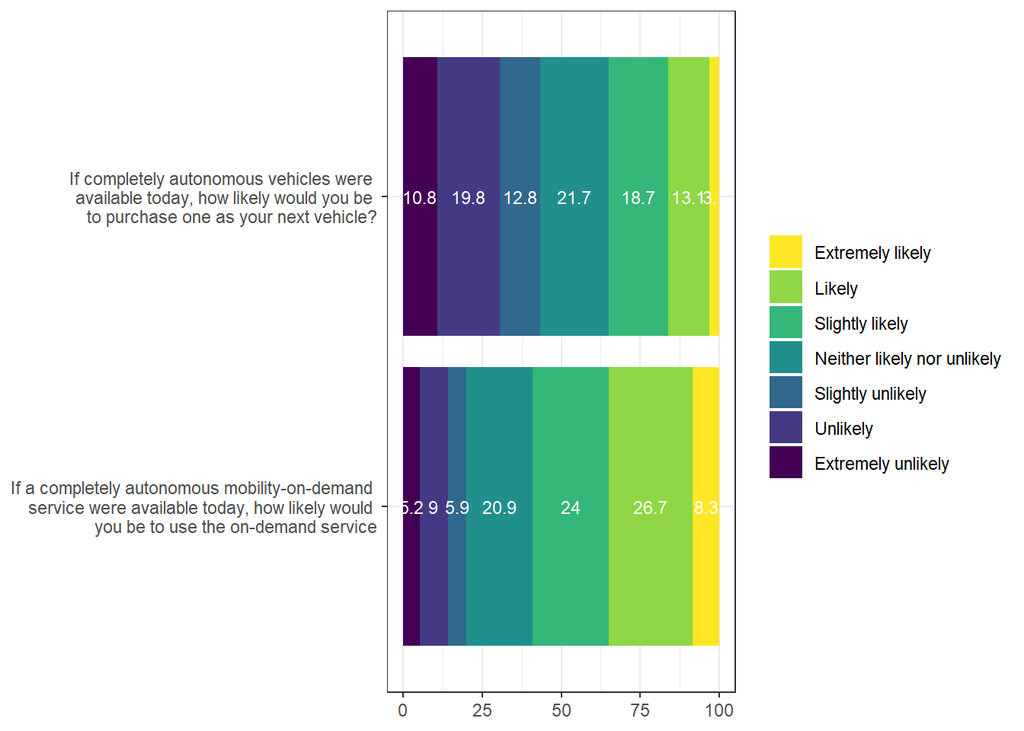

```r
Likert_data <- rbind(PAV_Purch_data, SAV_Intend_data)

pL <- ggplot(data=Likert_data, aes(x=question)) +
        geom_bar(aes(y=perc, fill=forcats::fct_rev(answer)), position="stack", stat="identity") +
        geom_text(size=3, color="white", aes(y=pos, label=round(perc,1)))+
        scale_fill_viridis(discrete=TRUE, direction=-1) +
        #coord_cartesian(ylim = c(0,100), expand=FALSE) +
        theme_bw() +
        theme(axis.title=element_blank(), legend.title=element_blank(), legend.position="right")+
        coord_flip()
pL
```

```r
## Difference in Intent to Purchase PAV and Intent to Use SAV
#Correlation across all individuals is 0.626, indicating that those who are more willing to use an SAV are also more willing to purchase a PAV (or vice versa)
cor(Data_SG$PAV_Purch, Data_SG$SAV_IntendUse_max)
```

```
## [1] 0.6261985
```

```r
summary(Data_SG$AV_IntendDiff)
```

```
##    Min. 1st Qu.  Median    Mean 3rd Qu.    Max.
## -6.0000 -2.0000 -1.0000 -0.9365  0.0000  3.0000
```

```r
length(which(Data_SG$AV_IntendDiff == 0)) #319
```

```
## [1] 319
```

```r
length(which(Data_SG$AV_IntendDiff < 0)) #422
```

```
## [1] 422
```

```r
length(which(Data_SG$AV_IntendDiff > 0)) #62
```

```
## [1] 62
```

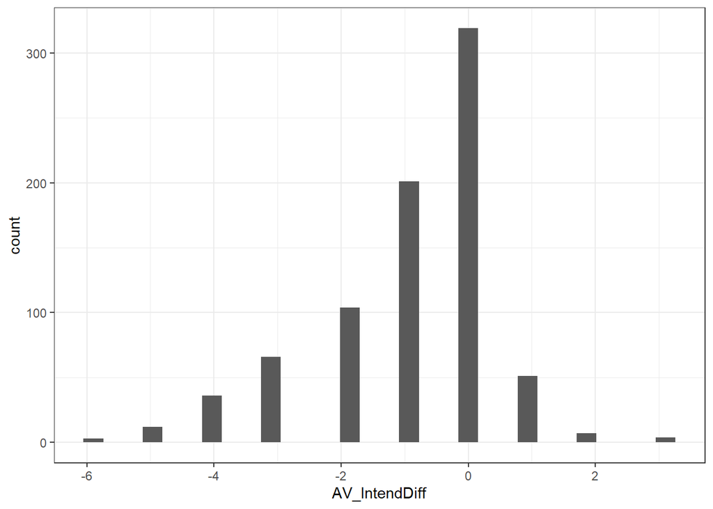

```r
#Positive indicates that intention to purchase a private AV is higher than intention to use fleet-based AV
ggplot(Data_SG, aes(x=AV_IntendDiff)) +
  geom_histogram() +
  theme_bw()
```

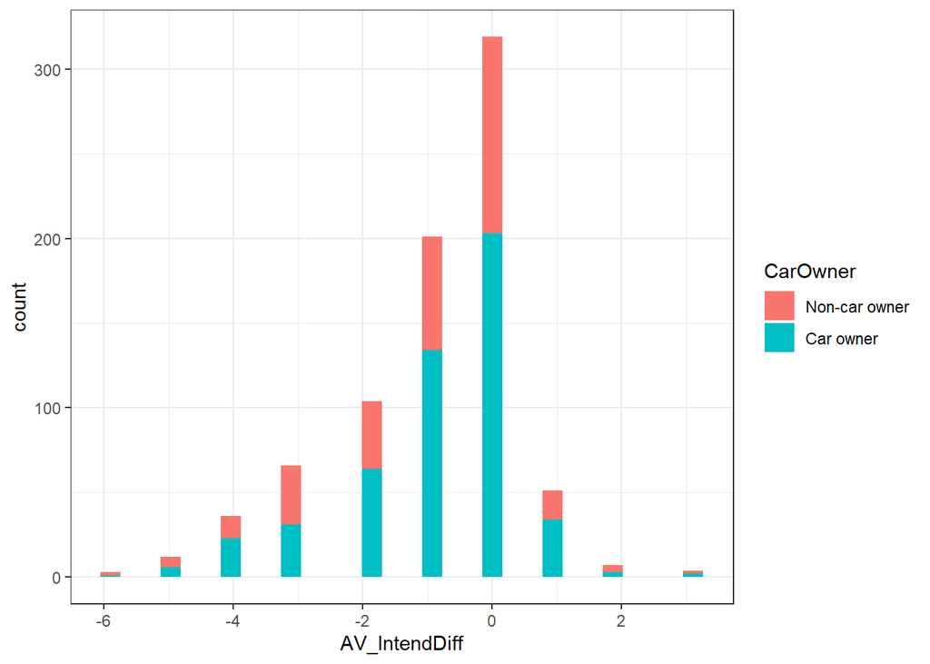

```r
ggplot(Data_SG, aes(x=AV_IntendDiff, group=CarOwner, fill=CarOwner)) +
  geom_histogram() +
  theme_bw()
```

### Intended Frequency of Use

PAV_Freq_1 = “If you owned a completely autonomous vehicle, what percentage of your trips would you take in it each month?” (Percentage of trips; 0-100)

SAV_Freq = “If you had ready access to a completely autonomous mobility-on-demand service, what percentage of your monthly trips would you take using the on-demand service”

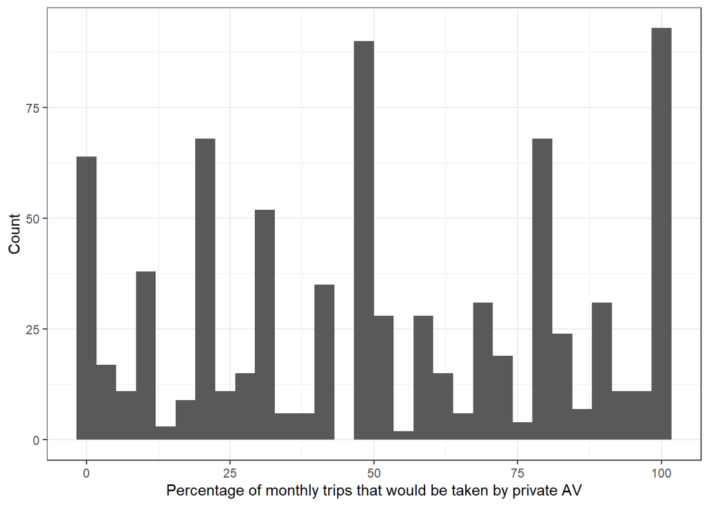

```r
###Private AVs
ggplot(Data_SG, aes(x=PAV_Freq)) +
  geom_histogram() +
  xlab("Percentage of monthly trips that would be taken by private AV") +
  ylab("Count")+
  theme_bw()
```

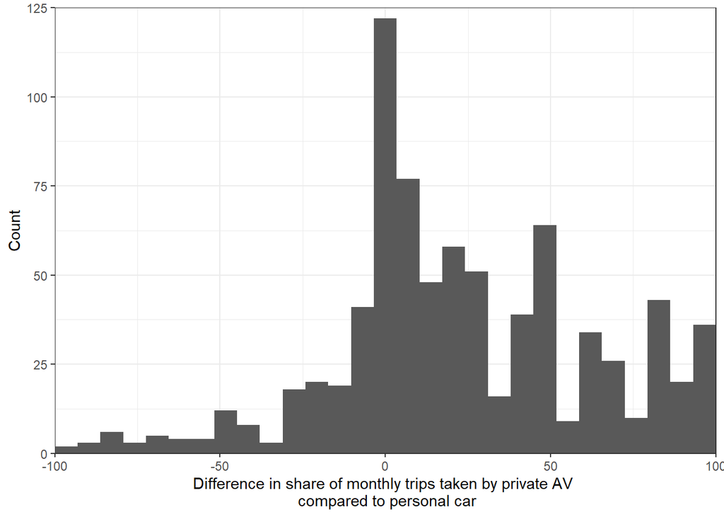

```r
ggplot(Data_SG, aes(x=PrivFreqDiff)) +
  geom_histogram() +
  xlab("Difference in share of monthly trips taken by private AV \n compared to personal car") +
  ylab("Count")+
  coord_cartesian(xlim=c(-100,100), ylim=c(0,125), expand=FALSE)+
  theme_bw()
```

```r
summary(Data_SG$PrivFreqDiff)
```

```
##    Min. 1st Qu.  Median    Mean 3rd Qu.    Max.
## -100.00    0.00   19.00   23.19   50.00  100.00
```

```r
length(which(Data_SG$PrivFreqDiff %in% -9:9)) #191 (24%)
```

```
## [1] 191
```

```r
length(which(Data_SG$PrivFreqDiff >= 10)) #490 (61%)
```

```
## [1] 490
```

```r
length(which(Data_SG$PrivFreqDiff <= -10)) #122 (15%)
```

```
## [1] 122
```

```r
summary(Data_SG_carowners$PrivFreqDiff)
```

```
##    Min. 1st Qu.  Median    Mean 3rd Qu.    Max.
## -100.00   -7.00    8.00    9.08   30.00  100.00
```

```r
length(which(Data_SG_carowners$PrivFreqDiff %in% -9:9)) #142 (28%)
```

```
## [1] 142
```

```r
length(which(Data_SG_carowners$PrivFreqDiff >= 10)) #241 (48%)
```

```
## [1] 241
```

```r
length(which(Data_SG_carowners$PrivFreqDiff <= -10)) #118 (24%)
```

```
## [1] 118
```

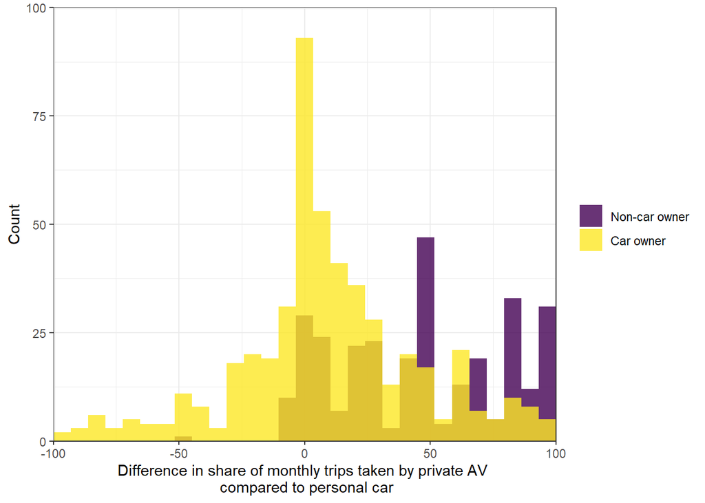

```r
ggplot(Data_SG, aes(x=PrivFreqDiff, group=CarOwner, fill=CarOwner)) +
  geom_histogram(alpha=0.8, position="identity") +
  scale_fill_viridis(discrete=TRUE) +
  xlab("Difference in share of monthly trips taken by private AV \n compared to personal car") +
  ylab("Count")+
  coord_cartesian(xlim=c(-100,100), ylim=c(0,100), expand=FALSE)+
  theme_bw()+
  theme(legend.title=element_blank())
```

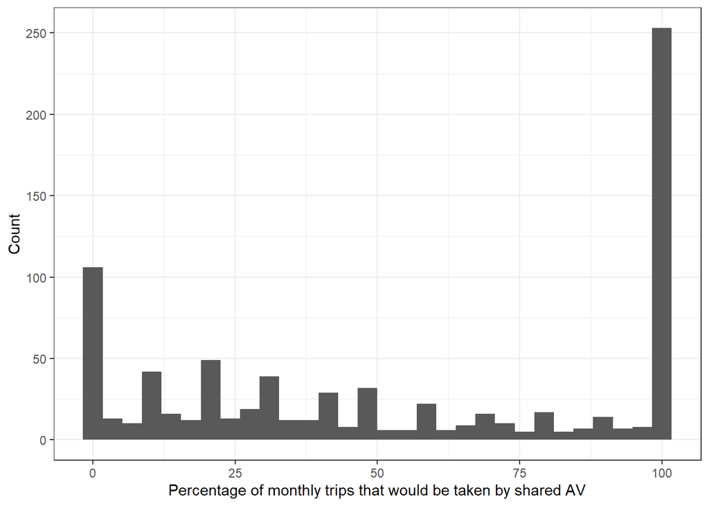

```r
###Fleet-based AVs
ggplot(Data_SG, aes(x=SAV_Freq)) +
  geom_histogram() +
  xlab("Percentage of monthly trips that would be taken by shared AV") +
  ylab("Count")+
  theme_bw()
```

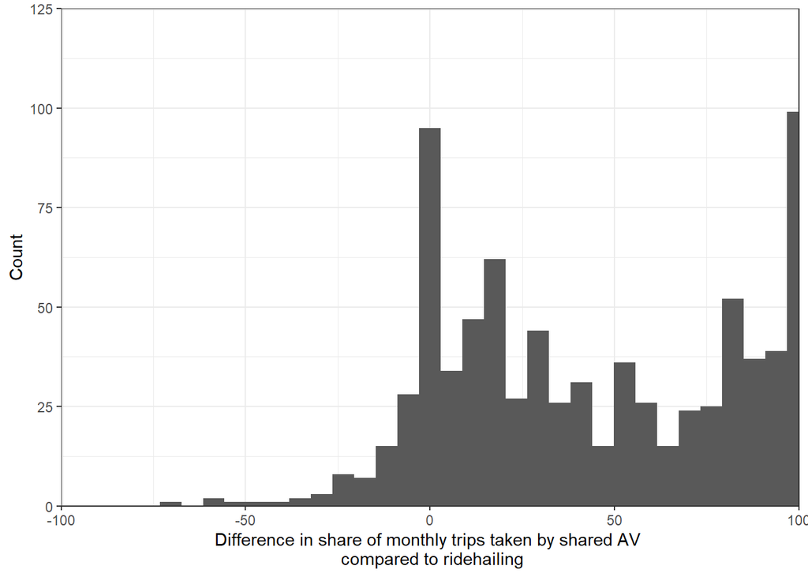

```r
ggplot(Data_SG, aes(x=FleetFreqDiff1)) +
  geom_histogram() +
  xlab("Difference in share of monthly trips taken by shared AV \n compared to ridehailing") +
  ylab("Count")+
  coord_cartesian(xlim=c(-100,100), ylim=c(0,125), expand=FALSE)+
  theme_bw()
```

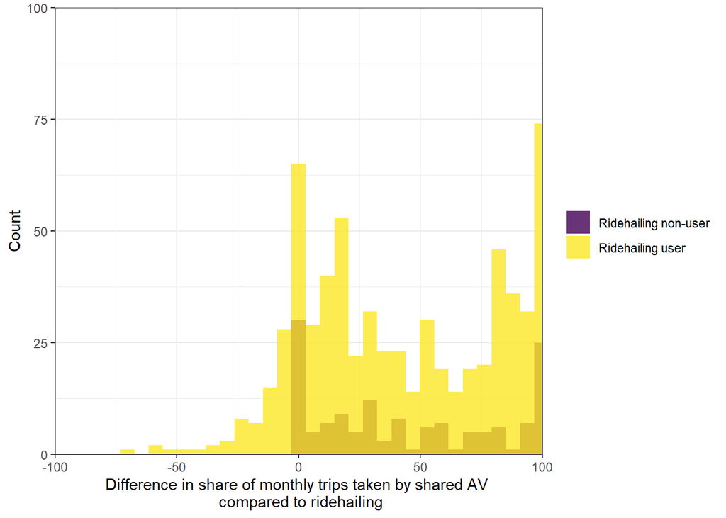

```r
Data_SG$RH_User_fct <- as.factor(as.character(Data_SG$RH_User))
levels(Data_SG$RH_User_fct) <- c("Ridehailing non-user", "Ridehailing user")

ggplot(Data_SG, aes(x=FleetFreqDiff1, group=RH_User_fct, fill=RH_User_fct)) +
  geom_histogram(alpha=0.8, position="identity") +
  scale_fill_viridis(discrete=TRUE) +
  xlab("Difference in share of monthly trips taken by shared AV \n compared to ridehailing") +
  ylab("Count")+
  coord_cartesian(xlim=c(-100,100), ylim=c(0,100), expand=FALSE)+
  theme_bw()+
  theme(legend.title=element_blank())
```

```r
summary(Data_SG$FleetFreqDiff1)
```

```
##    Min. 1st Qu.  Median    Mean 3rd Qu.    Max.
##  -70.00    9.00   37.00   42.93   81.00  100.00
```

```r
length(which(Data_SG$FleetFreqDiff1 %in% -9:9))
```

```
## [1] 164
```

```r
length(which(Data_SG$FleetFreqDiff1 >= 10))
```

```
## [1] 599
```

```r
length(which(Data_SG$FleetFreqDiff1 <= -10))
```

```
## [1] 40
```

```r
length(which(Data_SG$FleetFreqDiff1 == 100))
```

```
## [1] 80
```